# Chapter 4, Part 5: SARIMAX. AutoARIMA. Machine Learning Models.

- Show All Code
- Hide All Code

Machine Learning

Author

F.San Segundo & N.Rodríguez

Published

April 2026

**Setting the working directory**

We begin by using cd to make sure we are in the right folder.

**Hide the code**

```python
%cd /wd/4_5_SARIMAX_AutoARIMA_ML_Models
```

```
/wd/4_5_SARIMAX_AutoARIMA_ML_Models
```

# Session Setup

**Install additional libraries**

We install the required libraries from the [Nixtlaverse](https://nixtlaverse.nixtla.io/)

**Hide the code**

```python
import subprocess

def pip_install(package):
    result = subprocess.run(
        ["pip", "install", package],
        capture_output=True,
        text=True
    )
    if result.returncode != 0:
        print(f"Error installing {package}: {result.stderr}")
    else:
        print(f"Successfully installed {package}")

pip_install("fpppy")
pip_install("tsfeatures")
pip_install("pyreadr")
```

**Libraries**

Let us also load the libraries we will use.

**Hide the code**

```python
# 1. System and Environment Setup
import os
import sys
import warnings
import random
import datetime
from tqdm import tqdm

# Set environment variables and ignore specific warnings
os.environ["NIXTLA_ID_AS_COL"] = "true"
warnings.filterwarnings(
    "ignore",
    category=UserWarning,
    message=".*FigureCanvasAgg is non-interactive.*"
)

# 2. Core Data Science Stack
import numpy as np
import pandas as pd
import scipy.stats as stats
import statsmodels.api as sm
from statsmodels.tsa.stattools import adfuller, kpss
from statsmodels.tsa.seasonal import seasonal_decompose
from sklearn.preprocessing import StandardScaler



# from statsforecast.arima import ARIMASummary, ndiffs, nsdiffs


# # 3. Time Series & Machine Learning
# import pmdarima as pmd
# import yfinance as yf
# import rdatasets
# import pyreadr

# 4. Custom Utilities
# from fc_4_3_utils.utils import *
# from fpppy.utils import plot_series as plot_series_fpp
# from utilsforecast.plotting import plot_series as plot_series_utils


from coreforecast.scalers import boxcox, boxcox_lambda, inv_boxcox
from utilsforecast.evaluation import evaluate
from utilsforecast.losses import rmse, mape
from statsforecast import StatsForecast

from statsforecast.models import (
    HistoricAverage,
    RandomWalkWithDrift,
    SeasonalNaive,
)

from statsforecast.models import AutoARIMA


import lightgbm as lgb
import optuna


from mlforecast import MLForecast
from mlforecast.auto import (
    AutoLightGBM,
    AutoMLForecast)
from mlforecast.lag_transforms import ExpandingMean, RollingMean
from mlforecast.utils import generate_daily_series, generate_prices_for_series



# 5. Global Reproducibility & Display Settings
np.random.seed(1)
random.seed(1)
np.set_printoptions(suppress=True)

pd.set_option("max_colwidth", 100)
pd.set_option("display.precision", 3)

# 6. Plotting Configuration
import matplotlib as mpl
import matplotlib.pyplot as plt
import seaborn as sns
from cycler import cycler

# Jupyter Magic
%matplotlib inline

# Style and Aesthetics
plt.style.use("ggplot")
sns.set_style("whitegrid")

plt.rcParams.update({
    "figure.figsize": (8, 5),
    "figure.dpi": 100,
    "savefig.dpi": 300,
    "figure.constrained_layout.use": True,
    "axes.titlesize": 12,
    "axes.labelsize": 10,
    "xtick.labelsize": 9,
    "ytick.labelsize": 9,
    "legend.fontsize": 9,
    "legend.title_fontsize": 10,
})

# Custom color cycle (Example: monochromatic black as per your original)
mpl.rcParams['axes.prop_cycle'] = cycler(color=["#000000", "#000000"])
```

# Forecasting with exogenous variables.

**Exogenous variables in forecasting**

In many forecasting problems we use the values of one or more time series $X$ (called *exogenous* variables) to help us predict the time series $Y$ of interest (the *endogenous* variable). In this session we will see example of such forecasting models.

**Load the Dataset and preprocess it.**

This dataset contains the daily time series of the electricity demand for Spain in 2019-2020. We will initially load a simple table that only contains the date, demand, price and information about eolic generation. We will then take the oportunity to see how we can add potentially useful exogenous predictors from external sources, such as weather information and national holidays.

**Hide the code**

```python
use_preprocessed_data = False

if use_preprocessed_data:
    df_ts = pd.read_csv('./Electricity_Daily_Demand_Spain_2019_2020.csv')
else:
    df_ts = pd.read_csv('./DailyPrice_Load_Wind_Spain_2019_2020.csv', delimiter=';')

df_ts.head()
```

|  | Date | Demand | Wind | Price |
| --- | --- | --- | --- | --- |
| 0 | 01/01/2019 | 552.327 | 71.558 | 63.455 |
| 1 | 02/01/2019 | 704.500 | 180.946 | 60.541 |
| 2 | 03/01/2019 | 748.364 | 107.102 | 64.010 |
| 3 | 04/01/2019 | 754.509 | 75.455 | 66.836 |
| 4 | 05/01/2019 | 680.511 | 109.906 | 65.329 |

**Hide the code**

```python
if not use_preprocessed_data:
    df_ts.columns = ["ds", "Demand", "Wind", "Price"]
df_ts.head()
```

|  | ds | Demand | Wind | Price |
| --- | --- | --- | --- | --- |
| 0 | 01/01/2019 | 552.327 | 71.558 | 63.455 |
| 1 | 02/01/2019 | 704.500 | 180.946 | 60.541 |
| 2 | 03/01/2019 | 748.364 | 107.102 | 64.010 |
| 3 | 04/01/2019 | 754.509 | 75.455 | 66.836 |
| 4 | 05/01/2019 | 680.511 | 109.906 | 65.329 |

### Convert the ds column to datetime

**Hide the code**

```python
if not use_preprocessed_data:
    df_ts['ds'] = pd.to_datetime(df_ts['ds'], format='%d/%m/%Y')
else:
    df_ts['ds'] = pd.to_datetime(df_ts['ds'])
```

Now we can use `ds` as the index of the dataframe.

**Hide the code**

```python
time_idx = "ds"
df_ts.set_index(time_idx, drop=True, inplace=True)
df_ts.index.freq = 'D'
df_ts['unique_id'] = "Demand"
df_ts.head()
```

| ds | Demand | Wind | Price | unique_id |
| --- | --- | --- | --- | --- |
| 2019-01-01 | 552.327 | 71.558 | 63.455 | Demand |
| 2019-01-02 | 704.500 | 180.946 | 60.541 | Demand |
| 2019-01-03 | 748.364 | 107.102 | 64.010 | Demand |
| 2019-01-04 | 754.509 | 75.455 | 66.836 | Demand |
| 2019-01-05 | 680.511 | 109.906 | 65.329 | Demand |

**Hide the code**

```python
df_ts.info()
```

```
<class 'pandas.core.frame.DataFrame'>
DatetimeIndex: 731 entries, 2019-01-01 to 2020-12-31
Freq: D
Data columns (total 4 columns):
 #   Column     Non-Null Count  Dtype
---  ------     --------------  -----
 0   Demand     731 non-null    float64
 1   Wind       731 non-null    float64
 2   Price      731 non-null    float64
 3   unique_id  731 non-null    object
dtypes: float64(3), object(1)
memory usage: 28.6+ KB
```

Let us perform some basic EDA on the data. Note the scale of the variables.

**Hide the code**

```python
df_ts.describe()
```

|  | Demand | Wind | Price |
| --- | --- | --- | --- |
| count | 731.000 | 731.000 | 731.000 |
| mean | 666.602 | 146.595 | 40.811 |
| std | 72.646 | 79.587 | 11.855 |
| min | 474.176 | 25.824 | 1.942 |
| 25% | 614.105 | 86.297 | 33.987 |
| 50% | 675.454 | 127.955 | 42.006 |
| 75% | 718.880 | 187.340 | 49.014 |
| max | 828.297 | 408.183 | 69.427 |

**Hide the code**

```python
df_ts.nunique()
```

```
Demand       731
Wind         731
Price        727
unique_id      1
dtype: int64
```

**Hide the code**

```python
df_ts.head()
```

| ds | Demand | Wind | Price | unique_id |
| --- | --- | --- | --- | --- |
| 2019-01-01 | 552.327 | 71.558 | 63.455 | Demand |
| 2019-01-02 | 704.500 | 180.946 | 60.541 | Demand |
| 2019-01-03 | 748.364 | 107.102 | 64.010 | Demand |
| 2019-01-04 | 754.509 | 75.455 | 66.836 | Demand |
| 2019-01-05 | 680.511 | 109.906 | 65.329 | Demand |

There are no time gaps in the data.

**Hide the code**

```python
# Find start and end date of the rime series
start_date = df_ts.index.min()
end_date = df_ts.index.max()
# print(start_date, end_date)

# Generate a full range of months
full_range = pd.date_range(start=start_date, end=end_date, freq='D')  # 'MS' ensures month start

missing_dates = full_range.difference(df_ts.index)
missing_dates
```

```
DatetimeIndex([], dtype='datetime64[ns]', freq='D')
```

### Time plot of the series

**Hide the code**

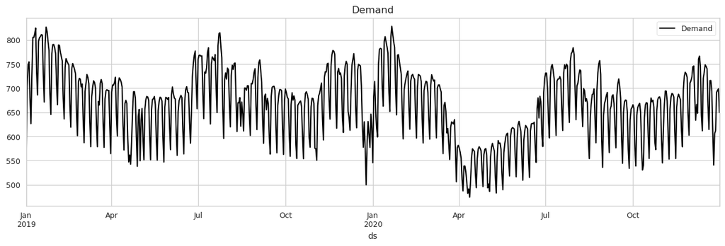

```python
if use_preprocessed_data:
    y_var = 'y'
else:
    y_var = 'Demand'
df_ts[[y_var]].plot(figsize=(12, 4), title="Demand")
plt.show();plt.close()
```

Note the **strong seasonality** in this data. Just by looking at the time plot it is clear that a seasonal naive model is bound to be a strong competitor for any of our forecasting models.

### Adding holidays info when using non preprocessed data

We will use the `holidays` library to add national holidays for SPain for the time period of interest:

**Hide the code**

```python
if not use_preprocessed_data:
    !pip install holidays
    import holidays
    from datetime import date

    # Initialize the Spain holiday object
    es_holidays = holidays.Spain(years=[start_date.year, end_date.year])

    df_ts['is_national_holiday'] = df_ts.index.to_series().apply(lambda x: x in es_holidays) * 1.0

df_ts.head()
```

[output not shown]

| ds | Demand | Wind | Price | unique_id | is_national_holiday |
| --- | --- | --- | --- | --- | --- |
| 2019-01-01 | 552.327 | 71.558 | 63.455 | Demand | 1.0 |
| 2019-01-02 | 704.500 | 180.946 | 60.541 | Demand | 0.0 |
| 2019-01-03 | 748.364 | 107.102 | 64.010 | Demand | 0.0 |
| 2019-01-04 | 754.509 | 75.455 | 66.836 | Demand | 0.0 |
| 2019-01-05 | 680.511 | 109.906 | 65.329 | Demand | 0.0 |

### Adding weather info (temperatures) when using non preprocessed data

**Hide the code**

```python
if not use_preprocessed_data:

    !pip install meteostat

    import meteostat as ms
    from datetime import datetime
    from tqdm import tqdm

    # Define the timeframe
    start = df_ts.index.min()
    end = df_ts.index.max()

    # Define the locations to be used
    locations = {
        'Madrid': ms.Point(40.4168, -3.7038, 650),
        'Barcelona': ms.Point(41.3851, 2.1734, 10),
        'Seville': ms.Point(37.3891, -5.9845, 10),
        'Bilbao': ms.Point(43.2630, -2.9350, 20)
    }

    # To store the results
    all_temps = pd.DataFrame()

    stations = ms.stations.nearby(locations['Madrid'], limit=1)
    print()
    print("-" * 50)
    print()
    print("Example stations:\n", stations)
```

```
WARNING: Running pip as the 'root' user can result in broken permissions and conflicting behaviour with the system package manager, possibly rendering your system unusable. It is recommended to use a virtual environment instead: https://pip.pypa.io/warnings/venv. Use the --root-user-action option if…



--------------------------------------------------



Example stations:

          name country region  latitude  longitude  elevation       timezone  \

id

08222  Madrid      ES      M    40.417     -3.683        655  Europe/Madrid



       distance

id

08222    1735.5
```

**Hide the code**

```python
if not use_preprocessed_data:

    for city, point in tqdm(locations.items()):
        # Find the nearest weather stations to this point
        stations = ms.stations.nearby(locations[city], limit=1)

        # Get daily data for those stations
        data = ms.daily(stations, start, end)

        # Optional: Use interpolation to account for altitude/distance
        # (Highly recommended for electricity demand models)
        df = ms.interpolate(data, locations[city]).fetch()
        # print(f"Data for {city}:\n", df.head())

        # Rename the average temperature column to the city name
        all_temps[city] = df['temp']

    print(all_temps.head())
```

```
            Madrid  Barcelona  Seville  Bilbao
time
2019-01-01     6.0        9.8      9.4     5.2
2019-01-02     5.6        7.9      8.2     7.2
2019-01-03     7.1        6.7      8.6     5.4
2019-01-04     5.2        6.2      9.7     2.9
2019-01-05     4.4        7.5      8.5     3.0
```

Now let us apply the population based weights:

**Hide the code**

```python
if not use_preprocessed_data:

    weights = {
        'Madrid': 0.18,
        'Barcelona': 0.17,
        'Seville': 0.15,
        'Bilbao': 0.05
    }

    weighted_temp = (
        (all_temps['Madrid'] * weights['Madrid']) +
        (all_temps['Barcelona'] * weights['Barcelona']) +
        (all_temps['Seville'] * weights['Seville']) +
        (all_temps['Bilbao'] * weights['Bilbao'])
    )

    df_ts['weighted_temp'] = weighted_temp
```

**Hide the code**

```python
df_ts.head()
```

| ds | Demand | Wind | Price | unique_id | is_national_holiday | weighted_temp |
| --- | --- | --- | --- | --- | --- | --- |
| 2019-01-01 | 552.327 | 71.558 | 63.455 | Demand | 1.0 | 4.416 |
| 2019-01-02 | 704.500 | 180.946 | 60.541 | Demand | 0.0 | 3.941 |
| 2019-01-03 | 748.364 | 107.102 | 64.010 | Demand | 0.0 | 3.977 |
| 2019-01-04 | 754.509 | 75.455 | 66.836 | Demand | 0.0 | 3.59 |
| 2019-01-05 | 680.511 | 109.906 | 65.329 | Demand | 0.0 | 3.492 |

**Hide the code**

```python
df_ts.tail()
```

| ds | Demand | Wind | Price | unique_id | is_national_holiday | weighted_temp |
| --- | --- | --- | --- | --- | --- | --- |
| 2020-12-27 | 612.205 | 276.251 | 26.505 | Demand | 0.0 | 2.991 |
| 2020-12-28 | 691.271 | 408.183 | 20.041 | Demand | 0.0 | 4.949 |
| 2020-12-29 | 695.576 | 323.441 | 38.662 | Demand | 0.0 | 4.099 |
| 2020-12-30 | 698.815 | 250.193 | 48.985 | Demand | 0.0 | 3.639 |
| 2020-12-31 | 649.801 | 233.342 | 48.660 | Demand | 0.0 | 3.477 |

## Using Nixtla format for the time series

As usual, we will make sure that the naming convention for the time series follows the Prophet/Nixtla standard.

**Hide the code**

```python
nxt_cols = ["unique_id", y_var]
df_ts = df_ts[nxt_cols + df_ts.columns.drop(nxt_cols).tolist()]
df_ts.head()
```

| ds | unique_id | Demand | Wind | Price | is_national_holiday | weighted_temp |
| --- | --- | --- | --- | --- | --- | --- |
| 2019-01-01 | Demand | 552.327 | 71.558 | 63.455 | 1.0 | 4.416 |
| 2019-01-02 | Demand | 704.500 | 180.946 | 60.541 | 0.0 | 3.941 |
| 2019-01-03 | Demand | 748.364 | 107.102 | 64.010 | 0.0 | 3.977 |
| 2019-01-04 | Demand | 754.509 | 75.455 | 66.836 | 0.0 | 3.59 |
| 2019-01-05 | Demand | 680.511 | 109.906 | 65.329 | 0.0 | 3.492 |

**Hide the code**

```python
if not use_preprocessed_data:
    df_ts.rename(columns={y_var: 'y'}, inplace=True)
df_ts.head()
```

| ds | unique_id | y | Wind | Price | is_national_holiday | weighted_temp |
| --- | --- | --- | --- | --- | --- | --- |
| 2019-01-01 | Demand | 552.327 | 71.558 | 63.455 | 1.0 | 4.416 |
| 2019-01-02 | Demand | 704.500 | 180.946 | 60.541 | 0.0 | 3.941 |
| 2019-01-03 | Demand | 748.364 | 107.102 | 64.010 | 0.0 | 3.977 |
| 2019-01-04 | Demand | 754.509 | 75.455 | 66.836 | 0.0 | 3.59 |
| 2019-01-05 | Demand | 680.511 | 109.906 | 65.329 | 0.0 | 3.492 |

**Hide the code**

```python
df_ts.describe()
```

|  | y | Wind | Price | is_national_holiday | weighted_temp |
| --- | --- | --- | --- | --- | --- |
| count | 731.000 | 731.000 | 731.000 | 731.000 | 710.0 |
| mean | 666.602 | 146.595 | 40.811 | 0.022 | 9.305 |
| std | 72.646 | 79.587 | 11.855 | 0.146 | 3.458 |
| min | 474.176 | 25.824 | 1.942 | 0.000 | 2.493 |
| 25% | 614.105 | 86.297 | 33.987 | 0.000 | 6.488 |
| 50% | 675.454 | 127.955 | 42.006 | 0.000 | 8.629 |
| 75% | 718.880 | 187.340 | 49.014 | 0.000 | 12.221 |
| max | 828.297 | 408.183 | 69.427 | 1.000 | 16.013 |

## Visualize the time series

**Hide the code**

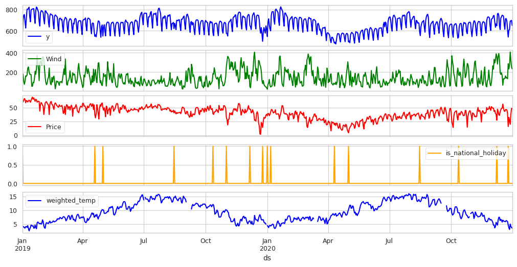

```python
df_ts.plot(
        subplots=True,
        layout=(df_ts.shape[1], 1),
        sharex=True,
        figsize=(10, 6),
        legend=True,
        color=["blue", "green", "red", "orange"][:df_ts.shape[1]]  # Adjust color list based on number of columns
    )
plt.show();plt.close()
```

### Checking missing data

Always check for missing data

**Hide the code**

```python
df_ts.isnull().sum()
```

```
unique_id               0
y                       0
Wind                    0
Price                   0
is_national_holiday     0
weighted_temp          21
dtype: int64
```

### Fill the gaps in the temp data if they are present

And use some imputation in that case

**Hide the code**

```python
if not use_preprocessed_data:
    df_ts["weighted_temp"] = df_ts["weighted_temp"].interpolate(method="linear")
```

### Save the data to a csv file

Now we have finished this feature engineering part of the process, If you want to run experiments with this data, iti is best to save the result as a separate data file. Then you can simply look for the `use_preprocessed_data` toggle variable above and switch it to `True`.

**Hide the code**

```python
if not use_preprocessed_data:
    df_ts.to_csv("Electricity_Daily_Demand_Spain_2019_2020.csv")
```

**Hide the code**

```python
print(f"Using preprocessed data: {use_preprocessed_data}")
```

```
Using preprocessed data: False
```

**Hide the code**

```python
df_ts.head()
```

| ds | unique_id | y | Wind | Price | is_national_holiday | weighted_temp |
| --- | --- | --- | --- | --- | --- | --- |
| 2019-01-01 | Demand | 552.327 | 71.558 | 63.455 | 1.0 | 4.416 |
| 2019-01-02 | Demand | 704.500 | 180.946 | 60.541 | 0.0 | 3.941 |
| 2019-01-03 | Demand | 748.364 | 107.102 | 64.010 | 0.0 | 3.977 |
| 2019-01-04 | Demand | 754.509 | 75.455 | 66.836 | 0.0 | 3.59 |
| 2019-01-05 | Demand | 680.511 | 109.906 | 65.329 | 0.0 | 3.492 |

**Hide the code**

```python
df_ts.tail()
```

| ds | unique_id | y | Wind | Price | is_national_holiday | weighted_temp |
| --- | --- | --- | --- | --- | --- | --- |
| 2020-12-27 | Demand | 612.205 | 276.251 | 26.505 | 0.0 | 2.991 |
| 2020-12-28 | Demand | 691.271 | 408.183 | 20.041 | 0.0 | 4.949 |
| 2020-12-29 | Demand | 695.576 | 323.441 | 38.662 | 0.0 | 4.099 |
| 2020-12-30 | Demand | 698.815 | 250.193 | 48.985 | 0.0 | 3.639 |
| 2020-12-31 | Demand | 649.801 | 233.342 | 48.660 | 0.0 | 3.477 |

### Temporal split into training and testing sets. Setting the forecasting horizon.

Since this is daily data, and from the EDA above, we expect a strong weekly seasonality. Our forecasting horizon will accordingly be a multiple of that weekly frequency 7. Initially we take one week, but you can run other experiments later.

**Hide the code**

```python
fh = 7
```

Now we are ready to split the data. We use the last 7 rows (last week) as test set. Keep in mind however that it is cross validation performance that matters the most to us.

**Hide the code**

```python
df_ts_train = df_ts.iloc[:-fh]
df_ts_test = df_ts.iloc[-fh:]
```

Let us check the split

**Hide the code**

```python
df_ts_train.tail()
```

| ds | unique_id | y | Wind | Price | is_national_holiday | weighted_temp |
| --- | --- | --- | --- | --- | --- | --- |
| 2020-12-20 | Demand | 614.474 | 135.965 | 43.422 | 0.0 | 5.937 |
| 2020-12-21 | Demand | 715.809 | 162.156 | 46.787 | 0.0 | 5.8 |
| 2020-12-22 | Demand | 715.913 | 140.147 | 46.710 | 0.0 | 6.205 |
| 2020-12-23 | Demand | 693.640 | 144.679 | 46.297 | 0.0 | 6.083 |
| 2020-12-24 | Demand | 609.158 | 133.280 | 39.939 | 0.0 | 5.882 |

**Hide the code**

```python
df_ts_test.head()
```

| ds | unique_id | y | Wind | Price | is_national_holiday | weighted_temp |
| --- | --- | --- | --- | --- | --- | --- |
| 2020-12-25 | Demand | 540.677 | 287.466 | 16.036 | 1.0 | 4.606 |
| 2020-12-26 | Demand | 605.961 | 234.149 | 32.864 | 0.0 | 3.597 |
| 2020-12-27 | Demand | 612.205 | 276.251 | 26.505 | 0.0 | 2.991 |
| 2020-12-28 | Demand | 691.271 | 408.183 | 20.041 | 0.0 | 4.949 |
| 2020-12-29 | Demand | 695.576 | 323.441 | 38.662 | 0.0 | 4.099 |

**Hide the code**

```python
df_ts_train.shape, df_ts_test.shape
```

```
((724, 6), (7, 6))
```

And visualize it:

**Hide the code**

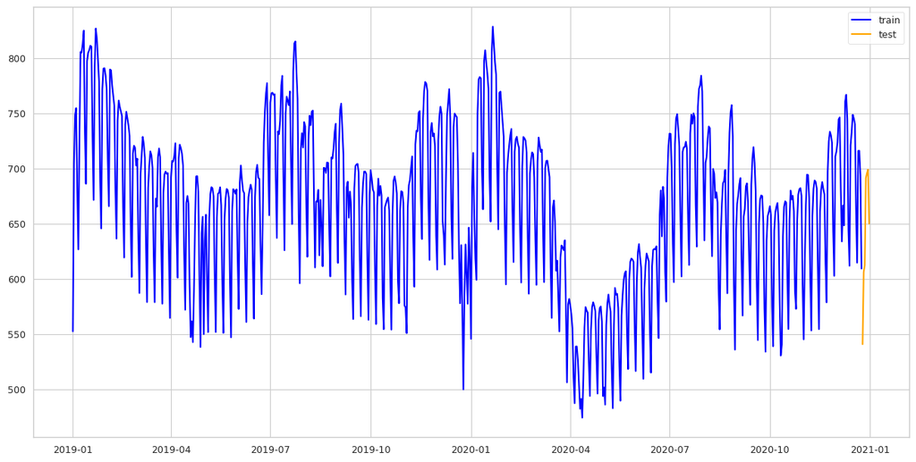

```python
fig, ax = plt.subplots(figsize=(12, 6))
ax.plot(df_ts_train['y'], label='train', color="blue")
ax.plot(df_ts_test['y'], label='test', color="orange")
ax.legend(["train", "test"])
plt.show();plt.close()
```

## Dealing with an Outlier

**Hide the code**

```python
outlier_idx = df_ts.index[np.argmin(df_ts[['y']])]
print(f"Outlier detected at index: {outlier_idx}, value: {df_ts.loc[outlier_idx, 'y']}")
```

```
Outlier detected at index: 2020-04-12 00:00:00, value: 474.176
```

In order to account for that we are going to introduce *delta* exogenous variable, with value 1 for that date and 0 for the rest, that will isolate the effect of that event in the model.

**Hide the code**

```python
df_ts_train['outlier'] = (df_ts_train.index == outlier_idx).astype(int)
outlier_pos = df_ts_train.index.get_loc(outlier_idx)
df_ts_train.iloc[max(0, outlier_pos - 2):outlier_pos + 3, :]
```

| ds | unique_id | y | Wind | Price | is_national_holiday | weighted_temp | outlier |
| --- | --- | --- | --- | --- | --- | --- | --- |
| 2020-04-10 | Demand | 482.228 | 82.083 | 19.071 | 1.0 | 8.133 | 0 |
| 2020-04-11 | Demand | 491.227 | 75.300 | 22.024 | 0.0 | 8.606 | 0 |
| 2020-04-12 | Demand | 474.176 | 99.278 | 17.818 | 0.0 | 8.789 | 1 |
| 2020-04-13 | Demand | 509.726 | 73.321 | 22.258 | 0.0 | 7.794 | 0 |
| 2020-04-14 | Demand | 555.961 | 97.909 | 21.952 | 0.0 | 8.101 | 0 |

We add the same variable to the test set (where it is just a column of zeros)

**Hide the code**

```python
df_ts_test['outlier'] = (df_ts_test.index == outlier_idx).astype(int)
# A sanity check
df_ts_test['outlier'].value_counts()
```

```
outlier
0    7
Name: count, dtype: int64
```

This is a very simple example of the set of techniques called *intervention analysis* (see [Hyndman et al. (2025), Chapter 7](https://otexts.com/fpppy/nbs/07-regression.html#intervention-variables)) that forecasters use to incorporate instantaneous or transient phenomena that may affect their predictions.

### Apply Box-Cox to the time series

We know that stabilizing the variance is a requirement of the ARIMA family of models. Therefore we examine visually the effect of a Box Cox transformation. In this case, as you will see below, it does not seem to be necessary or helpful.

**Hide the code**

```python
# from statsforecast.models import ARIMA

# 1. Find optimal lambda and transform Y manually
train_lambda = boxcox_lambda(df_ts_train['y'].values, method='guerrero', season_length=7)
df_ts_train_transformed = df_ts_train.copy()
df_ts_train_transformed['y_bxcx'] = boxcox(df_ts_train['y'].values, train_lambda)
```

**Hide the code**

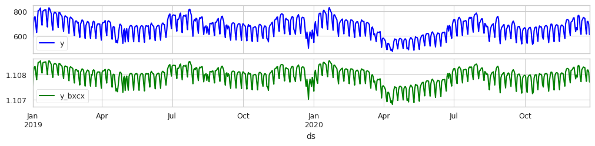

```python
df_ts_train_transformed[['y', 'y_bxcx']].plot(
        subplots=True,
        layout=(df_ts.shape[1], 1),
        sharex=True,
        figsize=(10, 6),
        legend=True,
        color=["blue", "green", "red", "orange"][:df_ts.shape[1]]  # Adjust color list based on number of columns
    )
plt.show();plt.close()
```

**Hide the code**

```python
use_BoxCox = False
if use_BoxCox:
    df_ts_train['y'] = df_ts_train_transformed['y_bxcx']
    df_ts_test['y'] = boxcox(df_ts_test['y'].values, train_lambda)
```

### Reset the index in train and test

We have used the temporal index for plotting, but some models below require `ds` to be a regular column:

**Hide the code**

```python
df_ts_train.reset_index(inplace=True)
df_ts_train.head()
```

|  | ds | unique_id | y | Wind | Price | is_national_holiday | weighted_temp | outlier |
| --- | --- | --- | --- | --- | --- | --- | --- | --- |
| 0 | 2019-01-01 | Demand | 552.327 | 71.558 | 63.455 | 1.0 | 4.416 | 0 |
| 1 | 2019-01-02 | Demand | 704.500 | 180.946 | 60.541 | 0.0 | 3.941 | 0 |
| 2 | 2019-01-03 | Demand | 748.364 | 107.102 | 64.010 | 0.0 | 3.977 | 0 |
| 3 | 2019-01-04 | Demand | 754.509 | 75.455 | 66.836 | 0.0 | 3.59 | 0 |
| 4 | 2019-01-05 | Demand | 680.511 | 109.906 | 65.329 | 0.0 | 3.492 | 0 |

**Hide the code**

```python
df_ts_test.reset_index(inplace=True)
df_ts_test.head()
```

|  | ds | unique_id | y | Wind | Price | is_national_holiday | weighted_temp | outlier |
| --- | --- | --- | --- | --- | --- | --- | --- | --- |
| 0 | 2020-12-25 | Demand | 540.677 | 287.466 | 16.036 | 1.0 | 4.606 | 0 |
| 1 | 2020-12-26 | Demand | 605.961 | 234.149 | 32.864 | 0.0 | 3.597 | 0 |
| 2 | 2020-12-27 | Demand | 612.205 | 276.251 | 26.505 | 0.0 | 2.991 | 0 |
| 3 | 2020-12-28 | Demand | 691.271 | 408.183 | 20.041 | 0.0 | 4.949 | 0 |
| 4 | 2020-12-29 | Demand | 695.576 | 323.441 | 38.662 | 0.0 | 4.099 | 0 |

### Scaling the exogenous variables

The scaling of the exogenous variables is crucial for many Machine Learning models. Besides, it provides a basic way of assessing the relative importance of the predictors in ARIMA type models, by examining the size of their coefficients. Note, however, that the interpretability of the coefficients becomes harder after normalization (similar interpretability concerns apply to the model if Box Cox is applied).

First observe the scales of the variables:

**Hide the code**

```python
df_ts_train.describe()
```

|  | ds | y | Wind | Price | is_national_holiday | weighted_temp | outlier |
| --- | --- | --- | --- | --- | --- | --- | --- |
| count | 724 | 724.000 | 724.000 | 724.000 | 724.000 | 724.0 | 724.000 |
| mean | 2019-12-28 12:00:00 | 666.840 | 145.232 | 40.885 | 0.021 | 9.385 | 0.001 |
| min | 2019-01-01 00:00:00 | 474.176 | 25.824 | 1.942 | 0.000 | 2.493 | 0.000 |
| 25% | 2019-06-30 18:00:00 | 614.433 | 85.950 | 34.254 | 0.000 | 6.532 | 0.000 |
| 50% | 2019-12-28 12:00:00 | 675.595 | 127.273 | 42.052 | 0.000 | 8.764 | 0.000 |
| 75% | 2020-06-26 06:00:00 | 719.229 | 185.731 | 49.077 | 0.000 | 12.275 | 0.000 |
| max | 2020-12-24 00:00:00 | 828.297 | 406.145 | 69.427 | 1.000 | 16.013 | 1.000 |
| std | NaN | 72.757 | 78.544 | 11.828 | 0.143 | 3.421 | 0.037 |

Now we scale the continuous exogenous inputs. Note that, as usual, we are avoiding data leakage from the train to test sets.

**Hide the code**

```python
# 1. Select the features to scale
features_to_scale = ['Price', 'Wind', 'weighted_temp']

# 2. Fit only on the training data
scaler = StandardScaler()
scaler.fit(df_ts_train[features_to_scale])

# 3. Create copies to avoid SettingWithCopy warnings
df_ts_train = df_ts_train.copy()
df_ts_test = df_ts_test.copy()

# 4. Apply the TRANSFORM using the training statistics to BOTH sets
df_ts_train[features_to_scale] = scaler.transform(df_ts_train[features_to_scale])
df_ts_test[features_to_scale] = scaler.transform(df_ts_test[features_to_scale])
```

**Hide the code**

```python
df_ts_train.describe()
```

|  | ds | y | Wind | Price | is_national_holiday | weighted_temp | outlier |
| --- | --- | --- | --- | --- | --- | --- | --- |
| count | 724 | 724.000 | 7.240e+02 | 7.240e+02 | 724.000 | 7.240e+02 | 724.000 |
| mean | 2019-12-28 12:00:00 | 666.840 | 2.454e-17 | -5.103e-16 | 0.021 | -1.767e-16 | 0.001 |
| min | 2019-01-01 00:00:00 | 474.176 | -1.521e+00 | -3.295e+00 | 0.000 | -2.016e+00 | 0.000 |
| 25% | 2019-06-30 18:00:00 | 614.433 | -7.553e-01 | -5.611e-01 | 0.000 | -8.346e-01 | 0.000 |
| 50% | 2019-12-28 12:00:00 | 675.595 | -2.288e-01 | 9.870e-02 | 0.000 | -1.815e-01 | 0.000 |
| 75% | 2020-06-26 06:00:00 | 719.229 | 5.160e-01 | 6.931e-01 | 0.000 | 8.453e-01 | 0.000 |
| max | 2020-12-24 00:00:00 | 828.297 | 3.324e+00 | 2.415e+00 | 1.000 | 1.939e+00 | 1.000 |
| std | NaN | 72.757 | 1.001e+00 | 1.001e+00 | 0.143 | 1.001e+00 | 0.037 |

### Separate target y and features X

**Hide the code**

```python
feature_cols = df_ts_train.columns.difference(['unique_id', 'ds', 'y']).tolist()
feature_cols
```

```
['Price', 'Wind', 'is_national_holiday', 'outlier', 'weighted_temp']
```

**Hide the code**

```python
y_train = df_ts_train[['unique_id', 'ds', 'y']]
X_train = df_ts_train[['unique_id', 'ds'] + feature_cols]
X_train.head()
```

|  | unique_id | ds | Price | Wind | is_national_holiday | outlier | weighted_temp |
| --- | --- | --- | --- | --- | --- | --- | --- |
| 0 | Demand | 2019-01-01 | 1.910 | -0.939 | 1.0 | 0 | -1.453 |
| 1 | Demand | 2019-01-02 | 1.663 | 0.455 | 0.0 | 0 | -1.592 |
| 2 | Demand | 2019-01-03 | 1.956 | -0.486 | 0.0 | 0 | -1.582 |
| 3 | Demand | 2019-01-04 | 2.196 | -0.889 | 0.0 | 0 | -1.695 |
| 4 | Demand | 2019-01-05 | 2.068 | -0.450 | 0.0 | 0 | -1.724 |

**Hide the code**

```python
y_test = df_ts_test[['unique_id', 'ds', 'y']]
X_test = df_ts_test[['unique_id', 'ds'] + feature_cols]
X_test.head()
```

|  | unique_id | ds | Price | Wind | is_national_holiday | outlier | weighted_temp |
| --- | --- | --- | --- | --- | --- | --- | --- |
| 0 | Demand | 2020-12-25 | -2.102 | 1.812 | 1.0 | 0 | -1.398 |
| 1 | Demand | 2020-12-26 | -0.679 | 1.133 | 0.0 | 0 | -1.693 |
| 2 | Demand | 2020-12-27 | -1.217 | 1.669 | 0.0 | 0 | -1.870 |
| 3 | Demand | 2020-12-28 | -1.764 | 3.350 | 0.0 | 0 | -1.298 |
| 4 | Demand | 2020-12-29 | -0.188 | 2.270 | 0.0 | 0 | -1.546 |

# SARIMAX: ARIMA with exogenous variables

**SARIMAX**

SARIMAX is a further extension of the SARIMA methodology in which we use one or more additional time series as external or **exogeneous predictors** of the time series of interest, which in this context is called **endogenous**. The underlying stochastic process theory is ruled by an equation such as:
$$y(t) = \beta_0 + \beta_1 x_1(t) + \cdots + \beta_m x_m(t) + v(t)$$
where:

1. $y(t)$ is the endogenous time series (the output variable to be predicted).
2. $x_{1;t}, \ldots, x_{m;t}$ are the exogenous time series.
3. $v(t)$ is a SARIMA error term. That is, $v(t)$ follows a SARIMA model with its own $(p, d, q)(P, D, Q)$ order structure and an associated white noise error term.

As you can see, SARIMAX models combine the ideas of multiple regression and SARIMA into a unified framework. Let us illustrate the SARIMAX methodology by using it with our example.

To speed things up in this session, we are going to resort to the AutoARIMA methodology. You can read about it from the creators of the method (Hyndman-Khandakar algorithm from 2008) in [Hyndman et al. (2025), Chapter 9](https://otexts.com/fpppy/nbs/09-arima.html#sec-arima-r)

In order to use it we will create a Statsforecast object with that model:

**Hide the code**

```python
Arima_exog = StatsForecast(models=[AutoARIMA(alias="AutoARIMA_Exog", season_length=fh)], freq="D")

Arima_exog.fit(df=df_ts_train)
```

```
StatsForecast(models=[AutoARIMA_Exog])
```

For ease of comparison below, we are giving the model a name (an *alias* in Nixtla’s jargon) and we create a list of models.

**Hide the code**

```python
model_list = [Arima_exog.models[0].alias]
model_list
```

```
['AutoARIMA_Exog']
```

Let us examine the order and coefficients of the model:

**Hide the code**

```python
from statsforecast.arima import ARIMASummary
Arima_exog_fit = Arima_exog.fitted_[0, 0].model_
print(ARIMASummary(Arima_exog_fit), "\n")
```

```
Regression with ARIMA(1,0,2)(1,1,1)[7] errors
```

**Hide the code**

```python
ARIMA_exog_coefs = list(Arima_exog_fit["coef"].items())
ARIMA_exog_coefs
```

```
[('ar1', np.float64(0.9533407952638836)),
 ('ma1', np.float64(0.031803472879165816)),
 ('ma2', np.float64(-0.1637943710960791)),
 ('sar1', np.float64(0.06917694834974544)),
 ('sma1', np.float64(-0.9173840149826176)),
 ('ex_1', np.float64(5.060996788170238)),
 ('ex_2', np.float64(9.960528945337249)),
 ('ex_3', np.float64(-61.7241823892767)),
 ('ex_4', np.float64(0.5301610550828573)),
 ('ex_5', np.float64(39.12984938724059))]
```

In another format and with extra model fit information:

**Hide the code**

```python
arma = pd.Series(dict(ARIMA_exog_coefs[:-len(feature_cols)]), name="ARMA Coefficients").round(3)
regr = pd.Series(dict(ARIMA_exog_coefs[-len(feature_cols):]), name="Regression Coefficients").round(3)
metrics = pd.Series({
    "sigma^2": Arima_exog_fit["sigma2"], "loglik": Arima_exog_fit["loglik"],
    "aic": Arima_exog_fit["aic"], "aicc": Arima_exog_fit["aicc"], "bic": Arima_exog_fit["bic"],
}, name="Metrics").round(2)
print(arma.to_frame(), "\n")
print(regr.to_frame(), "\n")
print(metrics.to_frame())
```

```
      ARMA Coefficients
ar1               0.953
ma1               0.032
ma2              -0.164
sar1              0.069
sma1             -0.917

      Regression Coefficients
ex_1                    5.061
ex_2                    9.961
ex_3                  -61.724
ex_4                    0.530
ex_5                   39.130

         Metrics
sigma^2   286.02
loglik  -3046.12
aic      6114.24
aicc     6114.62
bic      6164.57
```

### Visualizing fitted vs real in the training set

The fitted model returns the residuals and the input values (as `x`), so we can combine them to get the fitted values:

**Hide the code**

```python
Arima_exog_fitted =  pd.DataFrame({'Arima_exog_fitted' : Arima_exog_fit['x'] - Arima_exog_fit['residuals']})
Arima_exog_fitted.index = df_ts_train['ds']
Arima_exog_fitted.head()
```

| ds | Arima_exog_fitted |
| --- | --- |
| 2019-01-01 | 551.727 |
| 2019-01-02 | 703.814 |
| 2019-01-03 | 747.631 |
| 2019-01-04 | 753.771 |
| 2019-01-05 | 679.848 |

And plot the fitted vs the real values in the train set:

**Hide the code**

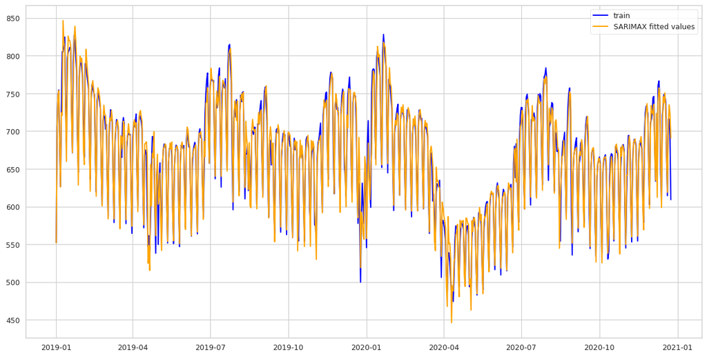

```python
fig, ax = plt.subplots(figsize=(12, 6))
ax.plot(df_ts_train.set_index('ds')['y'], label='train', color='blue')
ax.plot(Arima_exog_fitted['Arima_exog_fitted'], label=' SARIMAX model fitted values', color='orange')
ax.legend(["train", "SARIMAX fitted values"])
plt.show();plt.close()
```

### Visualizing predicted vs real in the test set

We always examine visually the result. First we get the test set predictions:

**Hide the code**

```python
X_test
```

|  | unique_id | ds | Price | Wind | is_national_holiday | outlier | weighted_temp |
| --- | --- | --- | --- | --- | --- | --- | --- |
| 0 | Demand | 2020-12-25 | -2.102 | 1.812 | 1.0 | 0 | -1.398 |
| 1 | Demand | 2020-12-26 | -0.679 | 1.133 | 0.0 | 0 | -1.693 |
| 2 | Demand | 2020-12-27 | -1.217 | 1.669 | 0.0 | 0 | -1.870 |
| 3 | Demand | 2020-12-28 | -1.764 | 3.350 | 0.0 | 0 | -1.298 |
| 4 | Demand | 2020-12-29 | -0.188 | 2.270 | 0.0 | 0 | -1.546 |
| 5 | Demand | 2020-12-30 | 0.685 | 1.337 | 0.0 | 0 | -1.681 |
| 6 | Demand | 2020-12-31 | 0.658 | 1.123 | 0.0 | 0 | -1.728 |

**Hide the code**

```python
Arima_exog_pred = Arima_exog.predict(h=fh, X_df=X_test)
Arima_exog_pred.head(min(10, fh))
```

|  | unique_id | ds | AutoARIMA_Exog |
| --- | --- | --- | --- |
| 0 | Demand | 2020-12-25 | 500.569 |
| 1 | Demand | 2020-12-26 | 499.656 |
| 2 | Demand | 2020-12-27 | 456.977 |
| 3 | Demand | 2020-12-28 | 585.029 |
| 4 | Demand | 2020-12-29 | 594.530 |
| 5 | Demand | 2020-12-30 | 592.636 |
| 6 | Demand | 2020-12-31 | 580.154 |

And now we plot them:

**Hide the code**

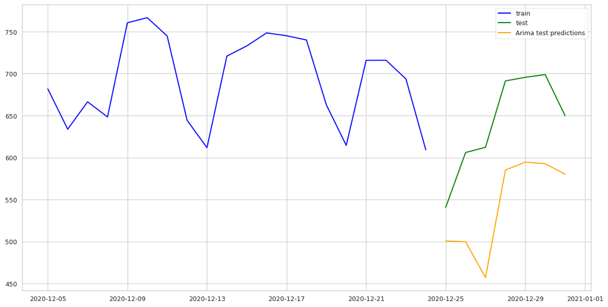

```python
plot_df = df_ts_test.set_index('ds')[['y']].copy()

fig, ax = plt.subplots(figsize=(12, 6))
ax.plot(df_ts_train.set_index('ds')['y'].tail(20), label='train', color='blue')
ax.plot(plot_df['y'], label='test', color='green')
ax.plot(Arima_exog_pred.set_index('ds')[Arima_exog.models[0].alias], label=' Arima test predictions', color='orange')
ax.legend(["train", "test", "Arima test predictions"])
plt.show();plt.close()
```

If the above plot seems disappointing, keep in mind that the test set coincidentally starts on Christmas, and besides it is really CV performance measures that we care about the most.

## Forecasting performance of the SARIMAX model

**Cross validation scores with SARIMAX Models**

We will use temporal cross validation to evaluate the model, in the same way we introduced for baseline models. The Nixtla framework makes it easy as we have seen.

We define the number of folds/windows to use. You can experiment with this value later.

**Hide the code**

```python
cv_windows = 10
```

We use `cross_validation` to create the folds (this took more than one minute on my machine):

**Hide the code**

```python
Arima_exog_cv_df = Arima_exog.cross_validation(
    df = df_ts_train.reset_index(),
    h = fh,
    step_size = 1,
    n_windows = cv_windows)

print(Arima_exog_cv_df.shape)
Arima_exog_cv_df.head()
```

```
(70, 5)
```

|  | unique_id | ds | cutoff | y | AutoARIMA_Exog |
| --- | --- | --- | --- | --- | --- |
| 0 | Demand | 2020-12-09 | 2020-12-08 | 760.563 | 719.610 |
| 1 | Demand | 2020-12-10 | 2020-12-08 | 766.606 | 756.487 |
| 2 | Demand | 2020-12-11 | 2020-12-08 | 744.742 | 745.518 |
| 3 | Demand | 2020-12-12 | 2020-12-08 | 644.426 | 670.412 |
| 4 | Demand | 2020-12-13 | 2020-12-08 | 611.717 | 620.897 |

This looks as expected:

**Hide the code**

```python
Arima_exog_cv_df.head(2 * fh)
```

|  | unique_id | ds | cutoff | y | AutoARIMA_Exog |
| --- | --- | --- | --- | --- | --- |
| 0 | Demand | 2020-12-09 | 2020-12-08 | 760.563 | 719.610 |
| 1 | Demand | 2020-12-10 | 2020-12-08 | 766.606 | 756.487 |
| 2 | Demand | 2020-12-11 | 2020-12-08 | 744.742 | 745.518 |
| 3 | Demand | 2020-12-12 | 2020-12-08 | 644.426 | 670.412 |
| 4 | Demand | 2020-12-13 | 2020-12-08 | 611.717 | 620.897 |
| 5 | Demand | 2020-12-14 | 2020-12-08 | 720.828 | 650.337 |
| 6 | Demand | 2020-12-15 | 2020-12-08 | 732.945 | 776.823 |
| 7 | Demand | 2020-12-10 | 2020-12-09 | 766.606 | 759.109 |
| 8 | Demand | 2020-12-11 | 2020-12-09 | 744.742 | 758.016 |
| 9 | Demand | 2020-12-12 | 2020-12-09 | 644.426 | 685.438 |
| 10 | Demand | 2020-12-13 | 2020-12-09 | 611.717 | 629.766 |
| 11 | Demand | 2020-12-14 | 2020-12-09 | 720.828 | 661.938 |
| 12 | Demand | 2020-12-15 | 2020-12-09 | 732.945 | 779.016 |
| 13 | Demand | 2020-12-16 | 2020-12-09 | 748.496 | 746.625 |

And now we use it to get the evaluation per fold:

**Hide the code**

```python
from utilsforecast.evaluation import evaluate
Arima_exog_eval = evaluate(Arima_exog_cv_df, metrics=[rmse, mape], models=[Arima_exog.models[0].alias])
Arima_exog_eval
```

|  | unique_id | cutoff | metric | AutoARIMA_Exog |
| --- | --- | --- | --- | --- |
| 0 | Demand | 2020-12-08 | rmse | 36.711 |
| 1 | Demand | 2020-12-09 | rmse | 33.454 |
| 2 | Demand | 2020-12-10 | rmse | 31.444 |
| 3 | Demand | 2020-12-11 | rmse | 33.664 |
| 4 | Demand | 2020-12-12 | rmse | 36.204 |
| 5 | Demand | 2020-12-13 | rmse | 35.791 |
| 6 | Demand | 2020-12-14 | rmse | 23.746 |
| 7 | Demand | 2020-12-15 | rmse | 16.148 |
| 8 | Demand | 2020-12-16 | rmse | 23.197 |
| 9 | Demand | 2020-12-17 | rmse | 43.183 |
| 10 | Demand | 2020-12-08 | mape | 0.040 |
| 11 | Demand | 2020-12-09 | mape | 0.038 |
| 12 | Demand | 2020-12-10 | mape | 0.032 |
| 13 | Demand | 2020-12-11 | mape | 0.035 |
| 14 | Demand | 2020-12-12 | mape | 0.039 |
| 15 | Demand | 2020-12-13 | mape | 0.039 |
| 16 | Demand | 2020-12-14 | mape | 0.025 |
| 17 | Demand | 2020-12-15 | mape | 0.017 |
| 18 | Demand | 2020-12-16 | mape | 0.025 |
| 19 | Demand | 2020-12-17 | mape | 0.047 |

The average performance metrics are:

**Hide the code**

```python
Arima_exog_eval.groupby("metric")[[Arima_exog.models[0].alias]].mean()
```

| metric | AutoARIMA_Exog |
| --- | --- |
| mape | 0.034 |
| rmse | 31.354 |

### Visualizing Cross Validation

Nixtla provides a very nice way of illustrating the result of cross validation for the different folds as follows:

**Hide the code**

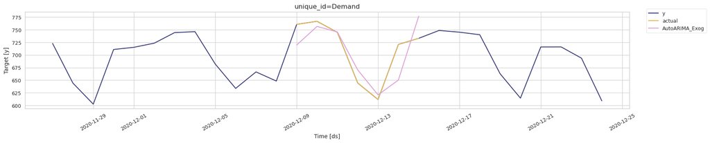

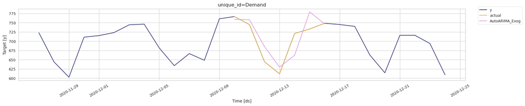

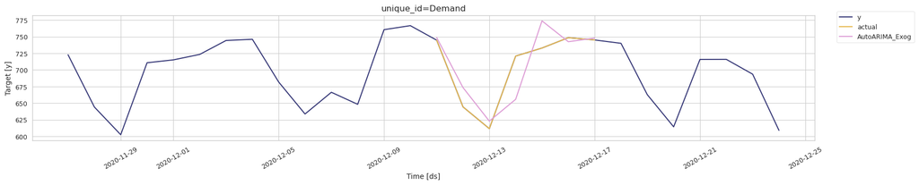

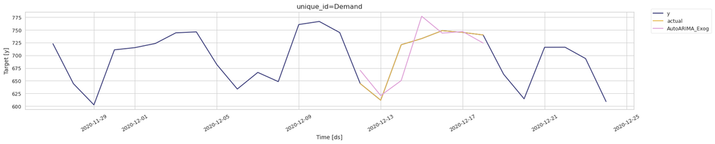

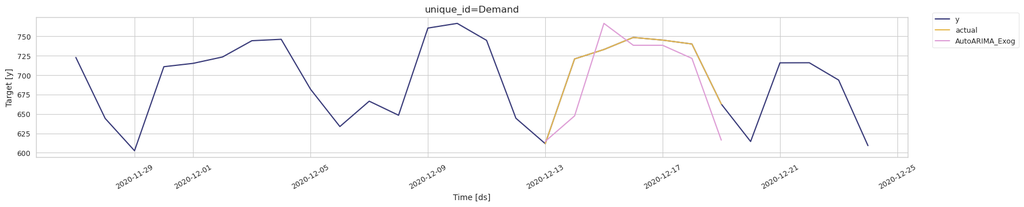

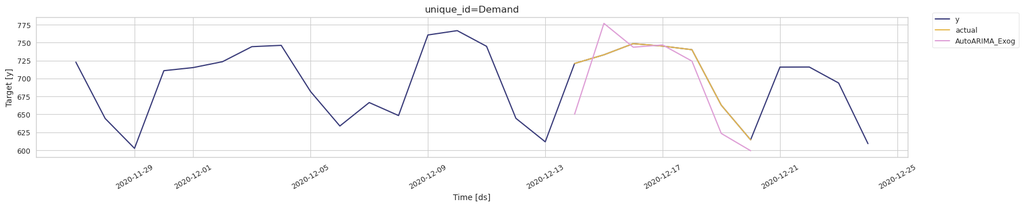

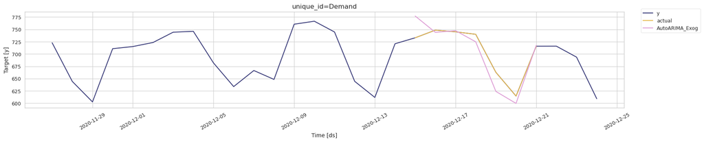

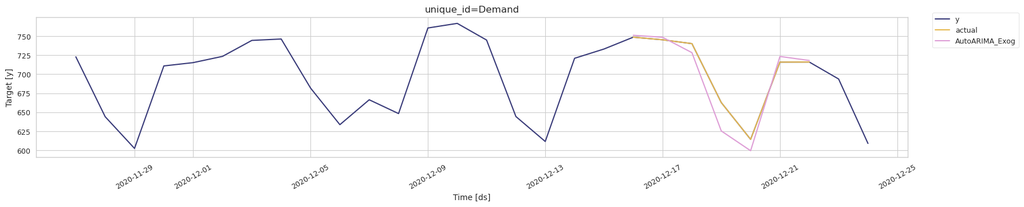

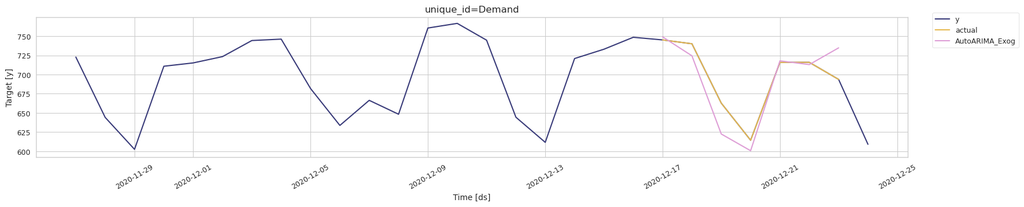

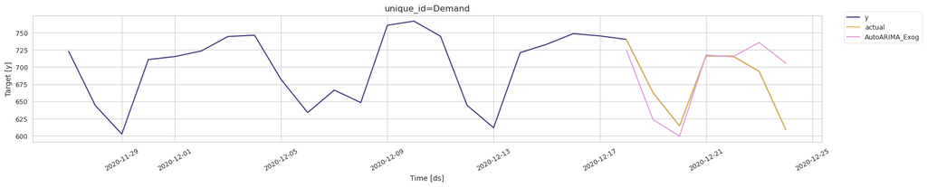

```python
Arima_exog_cv_df_plot = Arima_exog_cv_df.copy()
Arima_exog_cv_df_plot.rename(columns = {'y' : 'actual'}, inplace = True) # rename actual values

cutoff = Arima_exog_cv_df_plot['cutoff'].unique()

for k in range(len(cutoff)):
    cv = Arima_exog_cv_df_plot[Arima_exog_cv_df_plot['cutoff'] == cutoff[k]]
    display(StatsForecast.plot(df_ts_train.tail(4 * fh), cv.loc[:, cv.columns != 'cutoff']))
```

# Reference ARIMA model without exogenous variables and Baseline models

Are the above results good? We can not really say, until we compare them with other forecasting models. In particular, we should match them against the seasonal naive model, because as mentioned in this case it is going to be hard to beat. We will also throw into the mix a basic ARIMA model without exogenous variables and a couple of really basic baselines.

**Hide the code**

```python
model_no_exog = StatsForecast(models=[
    AutoARIMA(alias="AutoARIMA_NoExog", season_length=fh),
    RandomWalkWithDrift(alias='Drift'),
    HistoricAverage(alias='Mean'),
    SeasonalNaive(fh, alias='SeasonalNaive')],
    freq="D")
# model_exog = model_exog.fit(df=df_ts.reset_index(), target_col="y")
```

We update the model list:

**Hide the code**

```python
model_no_exog_list = [model.alias for model in model_no_exog.models]
model_no_exog_list
```

```
['AutoARIMA_NoExog', 'Drift', 'Mean', 'SeasonalNaive']
```

**IMPORTANT:** we will be using AutoARIMA again. But the way to make AutoARIMA notice that this model does not use exogenous variables is to **create a training dataset without those exogenous variables**.

**Hide the code**

```python
df_ts_train_no_exog = df_ts_train[['unique_id', 'ds', 'y']].copy()
df_ts_train_no_exog.head()
```

|  | unique_id | ds | y |
| --- | --- | --- | --- |
| 0 | Demand | 2019-01-01 | 552.327 |
| 1 | Demand | 2019-01-02 | 704.500 |
| 2 | Demand | 2019-01-03 | 748.364 |
| 3 | Demand | 2019-01-04 | 754.509 |
| 4 | Demand | 2019-01-05 | 680.511 |

We fit the model:

**Hide the code**

```python
model_no_exog.fit(df=df_ts_train_no_exog)
```

```
StatsForecast(models=[AutoARIMA_NoExog,Drift,Mean,SeasonalNaive])
```

**Hide the code**

```python
model_no_exog.fitted_
```

```
array([[AutoARIMA_NoExog, Drift, Mean, SeasonalNaive]], dtype=object)
```

And examine the order and coefficients. Note that this in fact a seasonal model:

**Hide the code**

```python
Arima_no_exog_fit = model_no_exog.fitted_[0, 0].model_
print(ARIMASummary(Arima_no_exog_fit), "\n")
```

```
ARIMA(2,0,1)(1,1,2)[7]
```

These is the model information:

**Hide the code**

```python
ARIMA_no_exog_coefs = list(Arima_no_exog_fit["coef"].items())
ARIMA_no_exog_coefs
```

```
[('ar1', np.float64(0.238331839193851)),
 ('ar2', np.float64(0.6137249179119741)),
 ('ma1', np.float64(0.7687112875439959)),
 ('sar1', np.float64(-0.06661808752236272)),
 ('sma1', np.float64(-0.7372423946751513)),
 ('sma2', np.float64(-0.1766567395459816))]
```

**Hide the code**

```python
arma = pd.Series(dict(ARIMA_no_exog_coefs), name="ARMA Coefficients").round(3)
metrics = pd.Series({
    "sigma^2": Arima_no_exog_fit["sigma2"], "loglik": Arima_no_exog_fit["loglik"],
    "aic": Arima_no_exog_fit["aic"], "aicc": Arima_no_exog_fit["aicc"], "bic": Arima_no_exog_fit["bic"],
}, name="Metrics").round(2)
print(arma.to_frame(), "\n")
print(metrics.to_frame())
```

```
      ARMA Coefficients
ar1               0.238
ar2               0.614
ma1               0.769
sar1             -0.067
sma1             -0.737
sma2             -0.177

         Metrics
sigma^2   497.69
loglik  -3247.16
aic      6508.32
aicc     6508.48
bic      6540.35
```

### Visualizing fitted vs real in the training set

**Hide the code**

```python
Arima_no_exog_fitted =  pd.DataFrame({'Arima_no_exog_fitted' : Arima_no_exog_fit['x'] - Arima_no_exog_fit['residuals']})
Arima_no_exog_fitted.index = df_ts_train['ds']
Arima_no_exog_fitted.head()
```

| ds | Arima_no_exog_fitted |
| --- | --- |
| 2019-01-01 | 551.775 |
| 2019-01-02 | 703.796 |
| 2019-01-03 | 747.615 |
| 2019-01-04 | 753.755 |
| 2019-01-05 | 679.831 |

**Hide the code**

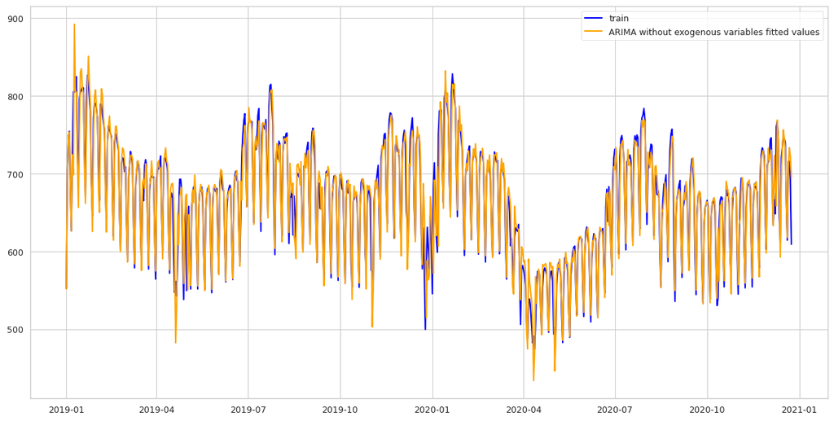

```python
fig, ax = plt.subplots(figsize=(12, 6))
ax.plot(df_ts_train.set_index('ds')['y'], label='train', color='blue')
ax.plot(Arima_no_exog_fitted['Arima_no_exog_fitted'], label=' ARIMA without exogenous variables fitted values', color='orange')
ax.legend(["train", "ARIMA without exogenous variables fitted values"])
plt.show();plt.close()
```

#### Visualizing predicted vs real in the test set

And now we get the models test set predictions and plot as we did before. But in order to do that we are going to create a table with all the models predictions, including our previous SARIMAX (with exogenous) variables.

**Hide the code**

```python
model_no_exog_pred = model_no_exog.predict(h=fh)
model_no_exog_pred.head(min(10, fh))
```

|  | unique_id | ds | AutoARIMA_NoExog | Drift | Mean | SeasonalNaive |
| --- | --- | --- | --- | --- | --- | --- |
| 0 | Demand | 2020-12-25 | 601.143 | 609.236 | 666.84 | 740.050 |
| 1 | Demand | 2020-12-26 | 541.964 | 609.315 | 666.84 | 662.777 |
| 2 | Demand | 2020-12-27 | 501.992 | 609.393 | 666.84 | 614.474 |
| 3 | Demand | 2020-12-28 | 603.638 | 609.472 | 666.84 | 715.809 |
| 4 | Demand | 2020-12-29 | 624.792 | 609.551 | 666.84 | 715.913 |
| 5 | Demand | 2020-12-30 | 639.029 | 609.629 | 666.84 | 693.640 |
| 6 | Demand | 2020-12-31 | 628.687 | 609.708 | 666.84 | 609.158 |

Uodate the model list:

**Hide the code**

```python
model_list = model_list + model_no_exog_list
model_list
```

```
['AutoARIMA_Exog', 'AutoARIMA_NoExog', 'Drift', 'Mean', 'SeasonalNaive']
```

Create the combined test predictions table:

**Hide the code**

```python
all_models__pred = model_no_exog_pred.copy()
all_models__pred["AutoARIMA_Exog"] = Arima_exog_pred[Arima_exog.models[0].alias]
all_models__pred
```

|  | unique_id | ds | AutoARIMA_NoExog | Drift | Mean | SeasonalNaive | AutoARIMA_Exog |
| --- | --- | --- | --- | --- | --- | --- | --- |
| 0 | Demand | 2020-12-25 | 601.143 | 609.236 | 666.84 | 740.050 | 500.569 |
| 1 | Demand | 2020-12-26 | 541.964 | 609.315 | 666.84 | 662.777 | 499.656 |
| 2 | Demand | 2020-12-27 | 501.992 | 609.393 | 666.84 | 614.474 | 456.977 |
| 3 | Demand | 2020-12-28 | 603.638 | 609.472 | 666.84 | 715.809 | 585.029 |
| 4 | Demand | 2020-12-29 | 624.792 | 609.551 | 666.84 | 715.913 | 594.530 |
| 5 | Demand | 2020-12-30 | 639.029 | 609.629 | 666.84 | 693.640 | 592.636 |
| 6 | Demand | 2020-12-31 | 628.687 | 609.708 | 666.84 | 609.158 | 580.154 |

And visualize them:

**Hide the code**

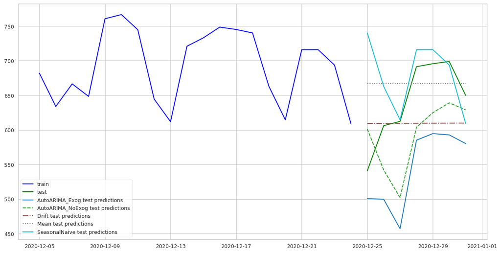

```python
plot_df = df_ts_test.set_index('ds')[['y']].copy()

legend_labels = []
# Dynamically generate colors using the 'tab10' colormap
num_models = len(model_list)
colors = plt.cm.get_cmap('tab10', num_models)
linestyles = ['-', '--', '-.', ':']


fig, ax = plt.subplots(figsize=(12, 6))
ax.plot(df_ts_train.set_index('ds')['y'].tail(20), label='train', color='blue')
ax.plot(plot_df['y'], label='test', color='green')
for i, model in enumerate(model_list):
    ax.plot(all_models__pred.set_index('ds')[model],
            label=f'{model} test predictions',
            color=colors(i),
            linestyle=linestyles[i % len(linestyles)])
    legend_labels += [f'{model} test predictions']
# ax.plot(Arima_exog_pred.set_index('ds')[Arima_exog.models[0].alias], label=' Arima test predictions', color='orange')
ax.legend(["train", "test"] + legend_labels)
plt.show();plt.close()
```

### Cross validation for reference models

Again, the performance measure that matters the most to us is the cross validation results, as it indicates the variability of the performance as the time series evolves in time.

**Hide the code**

```python
model_no_exog_cv_df = model_no_exog.cross_validation(
    df = df_ts_train_no_exog.reset_index(),
    h = fh,
    step_size = 1,
    n_windows = cv_windows)

print(model_no_exog_cv_df.shape)
```

```
(70, 8)
```

The result looks like this:

**Hide the code**

```python
model_no_exog_cv_df.head()
```

|  | unique_id | ds | cutoff | y | AutoARIMA_NoExog | Drift | Mean | SeasonalNaive |
| --- | --- | --- | --- | --- | --- | --- | --- | --- |
| 0 | Demand | 2020-12-09 | 2020-12-08 | 760.563 | 723.419 | 648.443 | 666.052 | 723.344 |
| 1 | Demand | 2020-12-10 | 2020-12-08 | 766.606 | 744.356 | 648.579 | 666.052 | 744.282 |
| 2 | Demand | 2020-12-11 | 2020-12-08 | 744.742 | 746.184 | 648.715 | 666.052 | 746.109 |
| 3 | Demand | 2020-12-12 | 2020-12-08 | 644.426 | 681.864 | 648.850 | 666.052 | 681.790 |
| 4 | Demand | 2020-12-13 | 2020-12-08 | 611.717 | 633.821 | 648.986 | 666.052 | 633.746 |

And here we also want to combine this with the previous SARIMAX model:

**Hide the code**

```python
all_models_cv_df = Arima_exog_cv_df.copy()
all_models_cv_df.head()
```

|  | unique_id | ds | cutoff | y | AutoARIMA_Exog |
| --- | --- | --- | --- | --- | --- |
| 0 | Demand | 2020-12-09 | 2020-12-08 | 760.563 | 719.610 |
| 1 | Demand | 2020-12-10 | 2020-12-08 | 766.606 | 756.487 |
| 2 | Demand | 2020-12-11 | 2020-12-08 | 744.742 | 745.518 |
| 3 | Demand | 2020-12-12 | 2020-12-08 | 644.426 | 670.412 |
| 4 | Demand | 2020-12-13 | 2020-12-08 | 611.717 | 620.897 |

**Hide the code**

```python
model_no_exog_list = [model.alias for model in model_no_exog.models]
model_no_exog_list
```

```
['AutoARIMA_NoExog', 'Drift', 'Mean', 'SeasonalNaive']
```

We use this loop to add ant the model CV information:

**Hide the code**

```python
for model in model_no_exog_list:
    print(f"Adding {model} predictions to all_models_cv_df...")
    all_models_cv_df[model] = model_no_exog_cv_df[model]

all_models_cv_df.head()
```

```
Adding AutoARIMA_NoExog predictions to all_models_cv_df...
Adding Drift predictions to all_models_cv_df...
Adding Mean predictions to all_models_cv_df...
Adding SeasonalNaive predictions to all_models_cv_df...
```

|  | unique_id | ds | cutoff | y | AutoARIMA_Exog | AutoARIMA_NoExog | Drift | Mean | SeasonalNaive |
| --- | --- | --- | --- | --- | --- | --- | --- | --- | --- |
| 0 | Demand | 2020-12-09 | 2020-12-08 | 760.563 | 719.610 | 723.419 | 648.443 | 666.052 | 723.344 |
| 1 | Demand | 2020-12-10 | 2020-12-08 | 766.606 | 756.487 | 744.356 | 648.579 | 666.052 | 744.282 |
| 2 | Demand | 2020-12-11 | 2020-12-08 | 744.742 | 745.518 | 746.184 | 648.715 | 666.052 | 746.109 |
| 3 | Demand | 2020-12-12 | 2020-12-08 | 644.426 | 670.412 | 681.864 | 648.850 | 666.052 | 681.790 |
| 4 | Demand | 2020-12-13 | 2020-12-08 | 611.717 | 620.897 | 633.821 | 648.986 | 666.052 | 633.746 |

This is how the result looks like:

**Hide the code**

```python
all_models_eval = evaluate(all_models_cv_df, metrics=[rmse, mape], models=model_list)
all_models_eval
```

|  | unique_id | cutoff | metric | AutoARIMA_Exog | AutoARIMA_NoExog | Drift | Mean | SeasonalNaive |
| --- | --- | --- | --- | --- | --- | --- | --- | --- |
| 0 | Demand | 2020-12-08 | rmse | 36.711 | 44.515 | 83.902 | 71.844 | 44.548 |
| 1 | Demand | 2020-12-09 | rmse | 33.454 | 44.891 | 74.894 | 69.604 | 42.514 |
| 2 | Demand | 2020-12-10 | rmse | 31.444 | 42.432 | 79.499 | 65.435 | 42.456 |
| 3 | Demand | 2020-12-11 | rmse | 33.664 | 42.468 | 64.127 | 64.583 | 42.489 |
| 4 | Demand | 2020-12-12 | rmse | 36.204 | 40.635 | 79.881 | 64.080 | 40.670 |
| 5 | Demand | 2020-12-13 | rmse | 35.791 | 39.790 | 108.101 | 63.803 | 39.822 |
| 6 | Demand | 2020-12-14 | rmse | 23.746 | 34.113 | 49.188 | 63.165 | 34.152 |
| 7 | Demand | 2020-12-15 | rmse | 16.148 | 13.693 | 54.135 | 60.829 | 13.580 |
| 8 | Demand | 2020-12-16 | rmse | 23.197 | 24.484 | 66.972 | 53.269 | 24.362 |
| 9 | Demand | 2020-12-17 | rmse | 43.183 | 56.380 | 82.645 | 49.266 | 56.269 |
| 10 | Demand | 2020-12-08 | mape | 0.040 | 0.052 | 0.102 | 0.093 | 0.052 |
| 11 | Demand | 2020-12-09 | mape | 0.038 | 0.050 | 0.082 | 0.091 | 0.047 |
| 12 | Demand | 2020-12-10 | mape | 0.032 | 0.048 | 0.092 | 0.087 | 0.047 |
| 13 | Demand | 2020-12-11 | mape | 0.035 | 0.048 | 0.063 | 0.086 | 0.048 |
| 14 | Demand | 2020-12-12 | mape | 0.039 | 0.044 | 0.101 | 0.082 | 0.044 |
| 15 | Demand | 2020-12-13 | mape | 0.039 | 0.039 | 0.133 | 0.082 | 0.039 |
| 16 | Demand | 2020-12-14 | mape | 0.025 | 0.029 | 0.055 | 0.081 | 0.029 |
| 17 | Demand | 2020-12-15 | mape | 0.017 | 0.016 | 0.057 | 0.078 | 0.016 |
| 18 | Demand | 2020-12-16 | mape | 0.025 | 0.025 | 0.078 | 0.067 | 0.025 |
| 19 | Demand | 2020-12-17 | mape | 0.047 | 0.053 | 0.105 | 0.066 | 0.053 |

The average metrics for the models over all folds are:

**Hide the code**

```python
all_models_eval.groupby("metric")[model_list].mean()
```

| metric | AutoARIMA_Exog | AutoARIMA_NoExog | Drift | Mean | SeasonalNaive |
| --- | --- | --- | --- | --- | --- |
| mape | 0.034 | 0.04 | 0.087 | 0.081 | 0.040 |
| rmse | 31.354 | 38.34 | 74.334 | 62.588 | 38.086 |

As expected, the Seasonal Naive is a strong competitor (even for the basic ARIMA) and only the SARIMAX model beats its performance. Let us visualize this fold by fold.

**Hide the code**

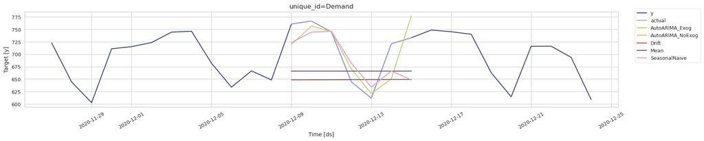

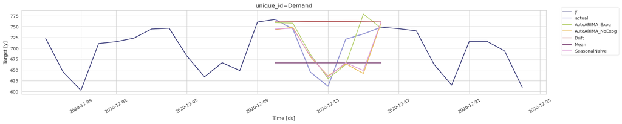

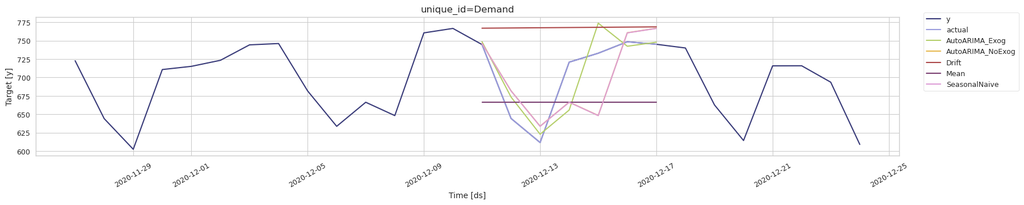

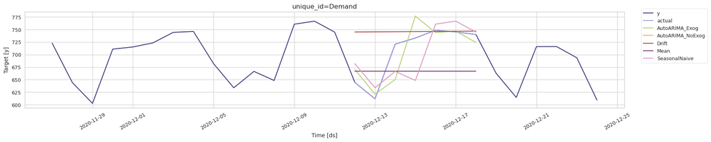

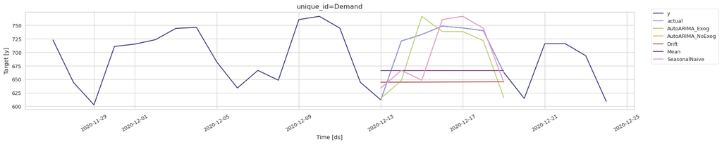

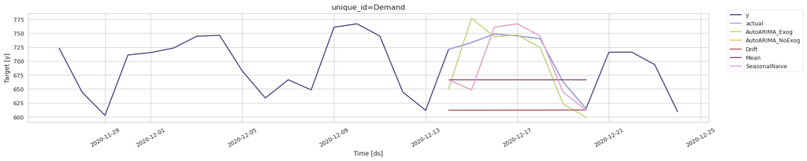

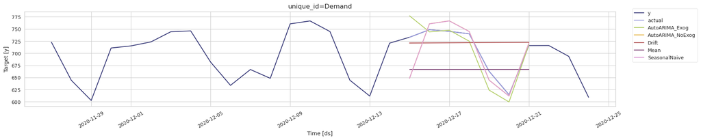

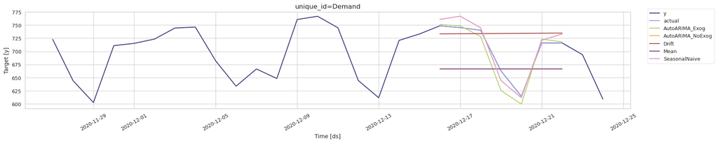

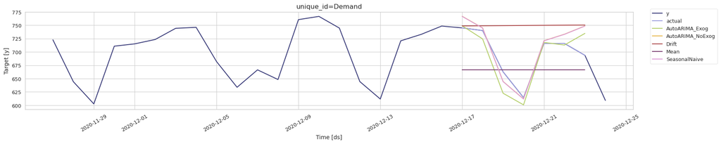

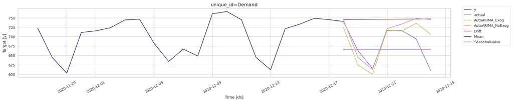

```python
all_models_cv_df_plot = all_models_cv_df.copy()
all_models_cv_df_plot.rename(columns = {'y' : 'actual'}, inplace = True) # rename actual values

cutoff = all_models_cv_df_plot['cutoff'].unique()

for k in range(len(cutoff)):
    cv = all_models_cv_df_plot[all_models_cv_df_plot['cutoff'] == cutoff[k]]
    display(StatsForecast.plot(df_ts_train.tail(4 * fh), cv.loc[:, cv.columns != 'cutoff'] ))
```

# Machine Learning Models with MLForecast

Most of the Machine Learning models for regression that we have seen in the course can be used for forecasting problems as well. The way to do this is to make them into autoregressive models by incorporating selected lags of the input variables into the training data. Here we will examine a gradient boosting model for the demand prediction problem. Our choice of model is not arbitrary; until very recently, boosting models have been the models of choice in forecasting competitions, replacing classical models as the ARIMA family. Nowadays, deep learning models are starting to become the most promising models.

Again, to speed things up for this session we are going to rely on the `AutoMLForecast` and `AutoLigghtGBM` classes provided by the MLForecast library of the NIxtlaverse. The code below should look familiar to waht we have done for the SARIMAX model, but we want to make two remarks:

- The `fit_config=lambda trial: {'static_features': []}` line is used to indicate that all of our exogenous library change over time. Sometimes, so called `static` exogenous variables are used in forecasting several time series, but we have none of those.
- When fitting a Machine Learning model we have learnt that hyperparameter optimization is an essential part of the process. The MLForecast library uses here the popular Optuna library for this task. Optuna performs a guided and smart search exploration of the hyperparameter space. The `num_samples=50` line of code selects the number of exploration trials that Optuna will take. When runnning this you will see that some of these trials are *pruned*, meaning that Optuna has come to the conclusion that they offer no improvement with respect the already explored regions. As for the choice of hyperparameters, `AutoMLForecast` and `AutoLightGBM` work together to make a good selection of those known to be important for these type of model. But you can certainly override their choices, see the documentation here: (https://nixtlaverse.nixtla.io/mlforecast/docs/how-to-guides/hyperparameter_optimization.html)

**Hide the code**

```python
AutoML_model_alias = "AutoLGBM"

AutoML_model = AutoMLForecast(
    models={AutoML_model_alias:AutoLightGBM()},
    freq='D',
    season_length=fh,
    fit_config=lambda trial: {'static_features': []},
    num_threads=2)


AutoML_model.fit(df=df_ts_train,
                 fitted=True,
                 n_windows=cv_windows * 4,
                 h=fh,
                 num_samples=50)  # number of Optuna trials to run)
```

[output not shown]

```
AutoMLForecast(models={'AutoLGBM': AutoModel(model=LGBMRegressor)})
```

Now we can extract the final model predictions for the test set and add them to the combined predictions table:

**Hide the code**

```python
X_test.head()
```

|  | unique_id | ds | Price | Wind | is_national_holiday | outlier | weighted_temp |
| --- | --- | --- | --- | --- | --- | --- | --- |
| 0 | Demand | 2020-12-25 | -2.102 | 1.812 | 1.0 | 0 | -1.398 |
| 1 | Demand | 2020-12-26 | -0.679 | 1.133 | 0.0 | 0 | -1.693 |
| 2 | Demand | 2020-12-27 | -1.217 | 1.669 | 0.0 | 0 | -1.870 |
| 3 | Demand | 2020-12-28 | -1.764 | 3.350 | 0.0 | 0 | -1.298 |
| 4 | Demand | 2020-12-29 | -0.188 | 2.270 | 0.0 | 0 | -1.546 |

**Hide the code**

```python
AutoML_preds = AutoML_model.predict(h=fh, X_df=X_test)
AutoML_preds
```

|  | unique_id | ds | AutoLGBM |
| --- | --- | --- | --- |
| 0 | Demand | 2020-12-25 | 617.746 |
| 1 | Demand | 2020-12-26 | 543.518 |
| 2 | Demand | 2020-12-27 | 500.846 |
| 3 | Demand | 2020-12-28 | 601.863 |
| 4 | Demand | 2020-12-29 | 615.855 |
| 5 | Demand | 2020-12-30 | 619.586 |
| 6 | Demand | 2020-12-31 | 613.632 |

**Hide the code**

```python
all_models__pred[AutoML_model_alias] = AutoML_preds[AutoML_model_alias]
all_models__pred
```

|  | unique_id | ds | AutoARIMA_NoExog | Drift | Mean | SeasonalNaive | AutoARIMA_Exog | AutoLGBM |
| --- | --- | --- | --- | --- | --- | --- | --- | --- |
| 0 | Demand | 2020-12-25 | 601.143 | 609.236 | 666.84 | 740.050 | 500.569 | 617.746 |
| 1 | Demand | 2020-12-26 | 541.964 | 609.315 | 666.84 | 662.777 | 499.656 | 543.518 |
| 2 | Demand | 2020-12-27 | 501.992 | 609.393 | 666.84 | 614.474 | 456.977 | 500.846 |
| 3 | Demand | 2020-12-28 | 603.638 | 609.472 | 666.84 | 715.809 | 585.029 | 601.863 |
| 4 | Demand | 2020-12-29 | 624.792 | 609.551 | 666.84 | 715.913 | 594.530 | 615.855 |
| 5 | Demand | 2020-12-30 | 639.029 | 609.629 | 666.84 | 693.640 | 592.636 | 619.586 |
| 6 | Demand | 2020-12-31 | 628.687 | 609.708 | 666.84 | 609.158 | 580.154 | 613.632 |

The final model is this one:

**Hide the code**

```python
ML_model = AutoML_model.models_[AutoML_model_alias]
ML_model

ML_model_alias ="lgbm"
```

And you can examine its parameters as follows:

**Hide the code**

```python
AutoML_model.results_[AutoML_model_alias].best_trial.user_attrs['config']
```

```
{'model_params': {'bagging_freq': 1,
  'learning_rate': 0.05,
  'verbosity': -1,
  'n_estimators': 133,
  'lambda_l1': 9.192505527908105,
  'lambda_l2': 0.06480484425792835,
  'num_leaves': 108,
  'feature_fraction': 0.7339813056347093,
  'bagging_fraction': 0.7372080431218551,
  'objective': 'l1'},
 'mlf_init_params': {'lags': [7, 28],
  'target_transforms': [<mlforecast.target_transforms.Differences at 0xffff5d75de50>,
   <mlforecast.target_transforms.LocalStandardScaler at 0xffff5d75ef90>],
  'lag_transforms': {1: [ExponentiallyWeightedMean(alpha=0.9)],
   7: [RollingMean(min_samples=1, window_size=7)]},
  'date_features': ['weekday', 'month', 'year'],
  'num_threads': 2},
 'mlf_fit_params': {'static_features': []}}
```

We update the model list:

**Hide the code**

```python
model_list +=  list(AutoML_model.models.keys())
model_list
```

```
['AutoARIMA_Exog',
 'AutoARIMA_NoExog',
 'Drift',
 'Mean',
 'SeasonalNaive',
 'AutoLGBM']
```

### Visualizing fitted vs real in the training set

The fitted model returns the fitted values through the `forecast_fitted_values` method after applying fit with `fitted = True`:

**Hide the code**

```python
df_ts_train.head()
```

|  | ds | unique_id | y | Wind | Price | is_national_holiday | weighted_temp | outlier |
| --- | --- | --- | --- | --- | --- | --- | --- | --- |
| 0 | 2019-01-01 | Demand | 552.327 | -0.939 | 1.910 | 1.0 | -1.453 | 0 |
| 1 | 2019-01-02 | Demand | 704.500 | 0.455 | 1.663 | 0.0 | -1.592 | 0 |
| 2 | 2019-01-03 | Demand | 748.364 | -0.486 | 1.956 | 0.0 | -1.582 | 0 |
| 3 | 2019-01-04 | Demand | 754.509 | -0.889 | 2.196 | 0.0 | -1.695 | 0 |
| 4 | 2019-01-05 | Demand | 680.511 | -0.450 | 2.068 | 0.0 | -1.724 | 0 |

**Hide the code**

```python
AutoML_model_fitted_df = AutoML_model.forecast_fitted_values()
AutoML_model_fitted_df.set_index('ds', inplace=True)
AutoML_model_fitted_df.head()
```

| ds | unique_id | y | AutoLGBM |
| --- | --- | --- | --- |
| 2019-01-30 | Demand | 790.628 | 793.990 |
| 2019-01-31 | Demand | 784.017 | 783.887 |
| 2019-02-01 | Demand | 771.496 | 775.842 |
| 2019-02-02 | Demand | 707.150 | 701.228 |
| 2019-02-03 | Demand | 665.659 | 663.561 |

And plot the fitted vs the real values in the train set:

**Hide the code**

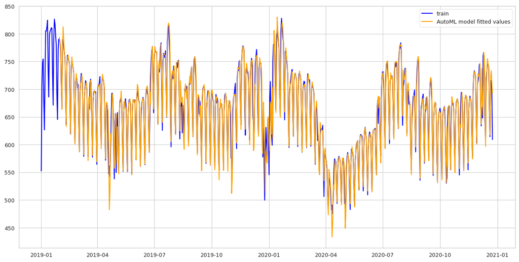

```python
fig, ax = plt.subplots(figsize=(12, 6))
ax.plot(df_ts_train.set_index('ds')['y'], label='train', color='blue')
ax.plot(AutoML_model_fitted_df[AutoML_model_alias], label='AutoML model fitted values', color='orange')
ax.legend(["train", "AutoML model fitted values"])
plt.show();plt.close()
```

Note that due to its automatic choices the ML model predictions start with a certain lag at the beginning of the training data set.

### Visualizing predicted vs real in the test set

We can also plot the test set predictions for all the models we have fitted so far:

**Hide the code**

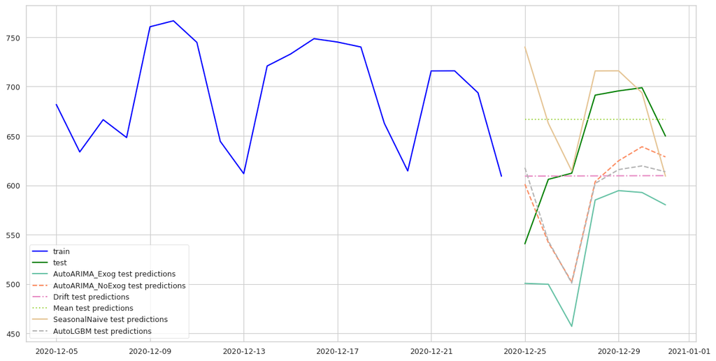

```python
plot_df = df_ts_test.set_index('ds')[['y']].copy()

legend_labels = []

# Dynamically generate colors using the 'tab10' colormap
num_models = len(model_list)
colors = plt.cm.get_cmap('Set2', num_models)
linestyles = ['-', '--', '-.', ':']


fig, ax = plt.subplots(figsize=(12, 6))
ax.plot(df_ts_train.set_index('ds')['y'].tail(20), label='train', color='blue')
ax.plot(plot_df['y'], label='test', color='green')
for i, model in enumerate(model_list):
    ax.plot(all_models__pred.set_index('ds')[model],
            label=f'{model} test predictions',
            color=colors(i),
            linestyle=linestyles[i % len(linestyles)])
    legend_labels += [f'{model} test predictions']
# ax.plot(Arima_exog_pred.set_index('ds')[Arima_exog.models[0].alias], label=' Arima test predictions', color='orange')
ax.legend(["train", "test"] + legend_labels)
plt.show();plt.close()
```

### Cross validation for Machine Learning models

Since the final model is a regular Nixtla model we proceed as above to get the CV performance measures:

**Hide the code**

```python
ML_model_cv_df = ML_model.cross_validation(
    df = df_ts_train,
    h = fh,
    static_features=[],
    step_size = 1,
    n_windows = cv_windows)

print(ML_model_cv_df.shape)
```

```
(70, 5)
```

**Hide the code**

```python
ML_model_cv_df.head(2 * fh)
```

|  | unique_id | ds | cutoff | y | AutoLGBM |
| --- | --- | --- | --- | --- | --- |
| 0 | Demand | 2020-12-09 | 2020-12-08 | 760.563 | 651.504 |
| 1 | Demand | 2020-12-10 | 2020-12-08 | 766.606 | 653.826 |
| 2 | Demand | 2020-12-11 | 2020-12-08 | 744.742 | 642.010 |
| 3 | Demand | 2020-12-12 | 2020-12-08 | 644.426 | 567.510 |
| 4 | Demand | 2020-12-13 | 2020-12-08 | 611.717 | 518.877 |
| 5 | Demand | 2020-12-14 | 2020-12-08 | 720.828 | 603.039 |
| 6 | Demand | 2020-12-15 | 2020-12-08 | 732.945 | 612.372 |
| 7 | Demand | 2020-12-10 | 2020-12-09 | 766.606 | 766.208 |
| 8 | Demand | 2020-12-11 | 2020-12-09 | 744.742 | 762.188 |
| 9 | Demand | 2020-12-12 | 2020-12-09 | 644.426 | 690.206 |
| 10 | Demand | 2020-12-13 | 2020-12-09 | 611.717 | 641.336 |
| 11 | Demand | 2020-12-14 | 2020-12-09 | 720.828 | 734.281 |
| 12 | Demand | 2020-12-15 | 2020-12-09 | 732.945 | 749.993 |
| 13 | Demand | 2020-12-16 | 2020-12-09 | 748.496 | 765.735 |

We add them to the combined model CV performance table for each fold:

**Hide the code**

```python
all_models_cv_df[AutoML_model_alias] = ML_model_cv_df[AutoML_model_alias]
all_models_cv_df.head()
```

|  | unique_id | ds | cutoff | y | AutoARIMA_Exog | AutoARIMA_NoExog | Drift | Mean | SeasonalNaive | AutoLGBM |
| --- | --- | --- | --- | --- | --- | --- | --- | --- | --- | --- |
| 0 | Demand | 2020-12-09 | 2020-12-08 | 760.563 | 719.610 | 723.419 | 648.443 | 666.052 | 723.344 | 651.504 |
| 1 | Demand | 2020-12-10 | 2020-12-08 | 766.606 | 756.487 | 744.356 | 648.579 | 666.052 | 744.282 | 653.826 |
| 2 | Demand | 2020-12-11 | 2020-12-08 | 744.742 | 745.518 | 746.184 | 648.715 | 666.052 | 746.109 | 642.010 |
| 3 | Demand | 2020-12-12 | 2020-12-08 | 644.426 | 670.412 | 681.864 | 648.850 | 666.052 | 681.790 | 567.510 |
| 4 | Demand | 2020-12-13 | 2020-12-08 | 611.717 | 620.897 | 633.821 | 648.986 | 666.052 | 633.746 | 518.877 |

And evaluate them:

**Hide the code**

```python
all_models_eval = evaluate(all_models_cv_df, metrics=[rmse, mape], models=model_list)
all_models_eval
```

|  | unique_id | cutoff | metric | AutoARIMA_Exog | AutoARIMA_NoExog | Drift | Mean | SeasonalNaive | AutoLGBM |
| --- | --- | --- | --- | --- | --- | --- | --- | --- | --- |
| 0 | Demand | 2020-12-08 | rmse | 36.711 | 44.515 | 83.902 | 71.844 | 44.548 | 105.637 |
| 1 | Demand | 2020-12-09 | rmse | 33.454 | 44.891 | 74.894 | 69.604 | 42.514 | 24.043 |
| 2 | Demand | 2020-12-10 | rmse | 31.444 | 42.432 | 79.499 | 65.435 | 42.456 | 17.619 |
| 3 | Demand | 2020-12-11 | rmse | 33.664 | 42.468 | 64.127 | 64.583 | 42.489 | 14.279 |
| 4 | Demand | 2020-12-12 | rmse | 36.204 | 40.635 | 79.881 | 64.080 | 40.670 | 32.573 |
| 5 | Demand | 2020-12-13 | rmse | 35.791 | 39.790 | 108.101 | 63.803 | 39.822 | 12.981 |
| 6 | Demand | 2020-12-14 | rmse | 23.746 | 34.113 | 49.188 | 63.165 | 34.152 | 20.483 |
| 7 | Demand | 2020-12-15 | rmse | 16.148 | 13.693 | 54.135 | 60.829 | 13.580 | 25.905 |
| 8 | Demand | 2020-12-16 | rmse | 23.197 | 24.484 | 66.972 | 53.269 | 24.362 | 33.719 |
| 9 | Demand | 2020-12-17 | rmse | 43.183 | 56.380 | 82.645 | 49.266 | 56.269 | 66.227 |
| 10 | Demand | 2020-12-08 | mape | 0.040 | 0.052 | 0.102 | 0.093 | 0.052 | 0.147 |
| 11 | Demand | 2020-12-09 | mape | 0.038 | 0.050 | 0.082 | 0.091 | 0.047 | 0.030 |
| 12 | Demand | 2020-12-10 | mape | 0.032 | 0.048 | 0.092 | 0.087 | 0.047 | 0.019 |
| 13 | Demand | 2020-12-11 | mape | 0.035 | 0.048 | 0.063 | 0.086 | 0.048 | 0.017 |
| 14 | Demand | 2020-12-12 | mape | 0.039 | 0.044 | 0.101 | 0.082 | 0.044 | 0.044 |
| 15 | Demand | 2020-12-13 | mape | 0.039 | 0.039 | 0.133 | 0.082 | 0.039 | 0.014 |
| 16 | Demand | 2020-12-14 | mape | 0.025 | 0.029 | 0.055 | 0.081 | 0.029 | 0.025 |
| 17 | Demand | 2020-12-15 | mape | 0.017 | 0.016 | 0.057 | 0.078 | 0.016 | 0.029 |
| 18 | Demand | 2020-12-16 | mape | 0.025 | 0.025 | 0.078 | 0.067 | 0.025 | 0.033 |
| 19 | Demand | 2020-12-17 | mape | 0.047 | 0.053 | 0.105 | 0.066 | 0.053 | 0.068 |

Finally we do the average for our last model comparison:

**Hide the code**

```python
all_models_eval.groupby("metric")[model_list].mean()
```

| metric | AutoARIMA_Exog | AutoARIMA_NoExog | Drift | Mean | SeasonalNaive | AutoLGBM |
| --- | --- | --- | --- | --- | --- | --- |
| mape | 0.034 | 0.04 | 0.087 | 0.081 | 0.040 | 0.043 |
| rmse | 31.354 | 38.34 | 74.334 | 62.588 | 38.086 | 35.347 |

For this particular problem you will see that the boosting model’s performance is close to that of the Seasonal Naive and basic Arima models. Again, the clear winner here is the SARIMAX model, as a reminder that these classical models are often still a good choice for many forecasting tasks.